# EDA Project Diamond Prices Part 3

```r
library(ggplot2)
library(dplyr)
library(tidyr)
```

## 1. Price Histograms with Facet and Color

Create a histogram of diamond prices. Facet the histogram by diamond color and use cut to color the histogram bars.

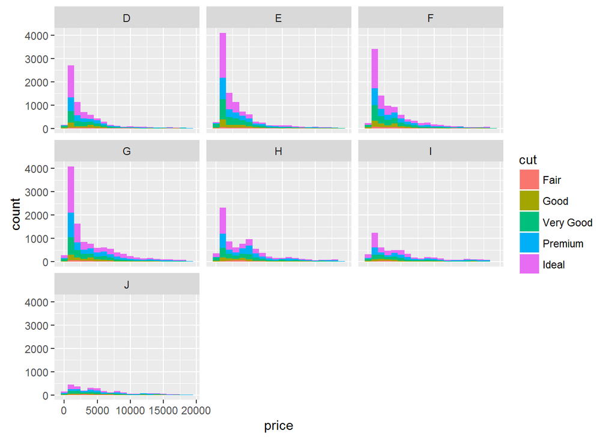

```r
ggplot(aes(x = price), data = diamonds) +
  geom_histogram(aes(fill = cut), binwidth = 1000) +
  facet_wrap(~ color)
```

## 2. Price vs. Table Colored by Cut

Create a scatterplot of diamond price vs.table and color the points by the cut of the diamond.

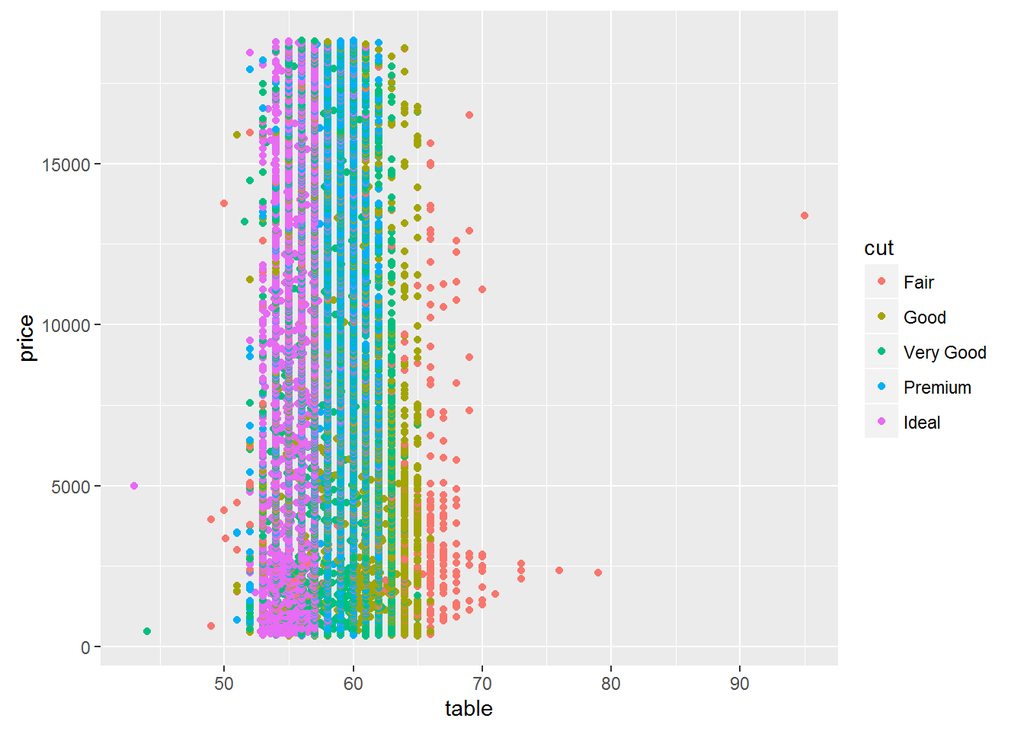

```r
ggplot(aes(y = price, x = table), data = diamonds) +
  geom_point(aes(color = cut))
```

## 3. Typical Table Value

Using the graph created:

What is the typical table range for the majority of diamonds of ideal cut? **53 - 57**

What is the typical table range for the majority of diamonds of premium cut? **58 - 62**

## 4. Price vs. Volume and Diamond Clarity

Create a scatterplot of diamond price vs.volume (x * y * z). Color the points by the clarity of diamonds. Use scale on the y-axis to take the log10 of price. Omit the top 1% of diamond volumes from the plot.

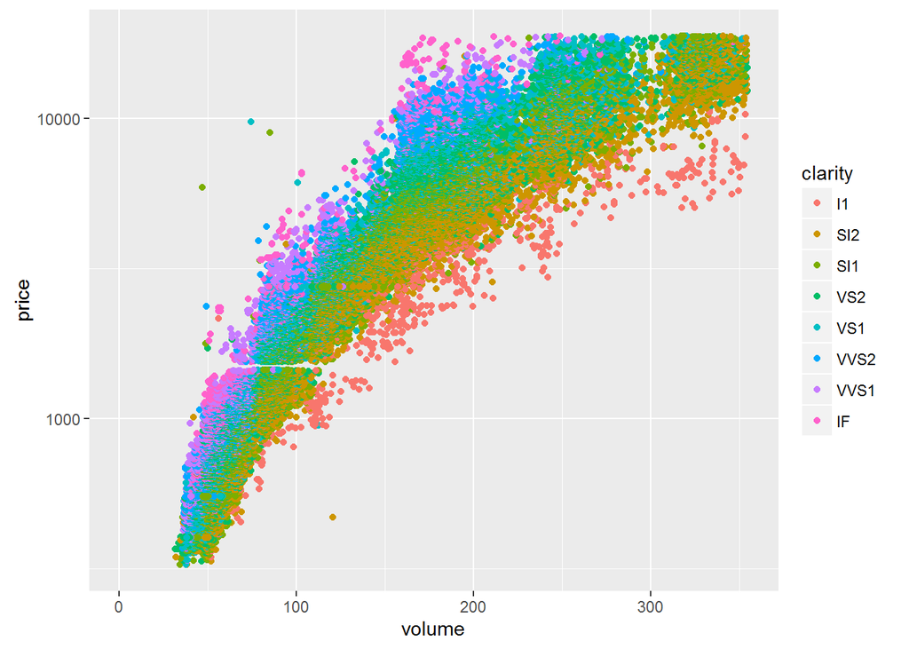

```r
diamonds$volume <- diamonds$x * diamonds$y * diamonds$z
ggplot(aes(y = price, x = volume), data = diamonds) +
  geom_point(aes(color = clarity)) +
  scale_y_log10() +
  xlim(1, quantile(diamonds$volume, 0.99))
```

## 5. Proportion of Friendships Initiated

Create a new variable called ’prop_initiated’in the Pseudo-Facebook data set. The variable should contain the proportion of friendships that the user initiated.

```r
pf <- read.csv("pseudo_facebook.tsv", sep = "\t")
pf$prop_initiated <- ifelse(pf$friend_count == 0, 0,
                            pf$friendships_initiated/pf$friend_count)
summary(pf$prop_initiated)
```

```
##    Min. 1st Qu.  Median    Mean 3rd Qu.    Max.
##  0.0000  0.4400  0.6184  0.5958  0.7795  1.0000
```

# 6. prop_initiated vs. tenure

Create a line graph of the median proportion of friendships initiated (‘prop_initiated’) vs. tenure and color the line segment by year_joined.bucket.

1. recreate buckets created in the lesson

```r
pf$year_joined <- floor(2014 - pf$tenure/365)
pf$year_joined.bucket <- cut(pf$year_joined,
                             breaks = c(2004, 2009, 2011, 2012, 2014))
```

2. filter data and examine results

```r
pf.median_prop <- pf %>%
  filter(!is.na(tenure)) %>%
  filter(tenure > 0) %>%
  group_by(tenure, year_joined.bucket) %>%
  summarise(median_prop_fr_init = median(prop_initiated),
            n = n()) %>%
  ungroup() %>%
  arrange(tenure)
head(pf.median_prop)
```

```
## Source: local data frame [6 x 4]
##
##   tenure year_joined.bucket median_prop_fr_init     n
##    (int)             (fctr)               (dbl) (int)
## 1      1        (2012,2014]           0.9027778    60
## 2      2        (2012,2014]           0.8571429    72
## 3      3        (2012,2014]           0.9000000    79
## 4      4        (2012,2014]           0.8285714    86
## 5      5        (2012,2014]           0.8321918    92
## 6      6        (2012,2014]           0.8947368    93
```

3. create plot

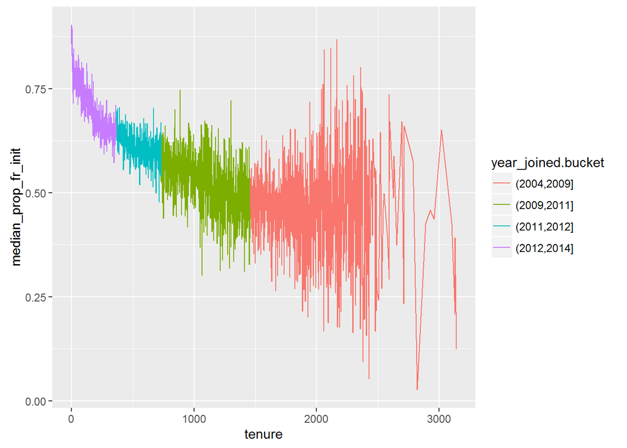

```r
ggplot(aes(y = median_prop_fr_init, x = tenure), data = pf.median_prop) +
  geom_line(aes(color = year_joined.bucket))
```

## 7. Smoothing prop_initiated vs. tenure

Smooth the last plot you created of of prop_initiated vs tenure colored by year_joined.bucket. Bin together ranges of tenure or add a smoother to the plot.

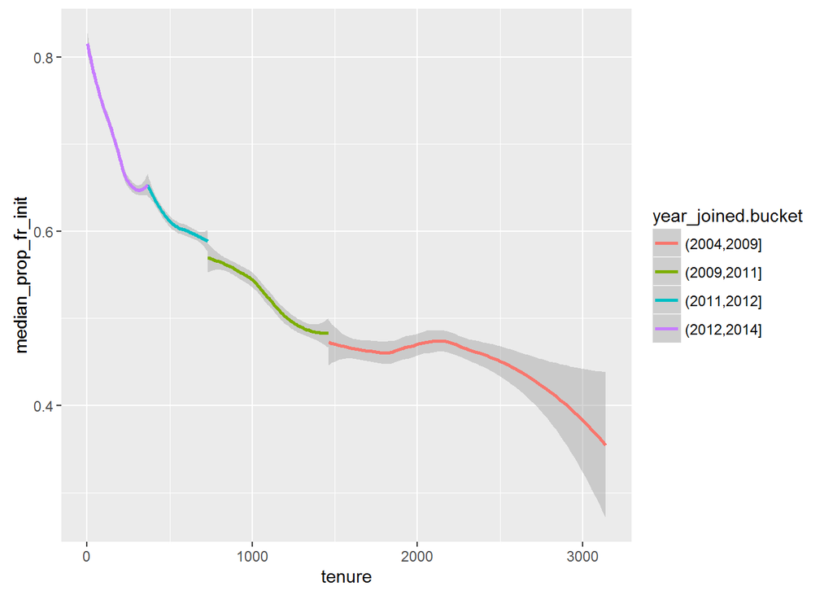

```r
ggplot(aes(y = median_prop_fr_init, x = tenure), data = pf.median_prop) +
  geom_smooth(aes(color = year_joined.bucket))
```

## 8. Greatest prop_initiated Group

On average, which group initiated the greatest propoertion of its Facebook friendships? **People who joined after 2012**

## 9. Largest Group Mean prop_initiated

For the group with the largest proportion of friendships initiated, what is the group’s average proportion of friendships initiated?

```r
with(subset(pf, year_joined.bucket == "(2012,2014]"), mean(prop_initiated))
```

```
## [1] 0.6430155
```

Why do you think this group’s proportion of frienships initiated is higher than others? **New users: they are more likely to request friendship from existing users**

## 10. Price/Carat Binned, Faceted, & Colored

Create a scatter plot of the price/carat ratio of diamonds. The variable x should be assigned to cut. The points should be colored by diamond color. The plot should be faceted by clarity.

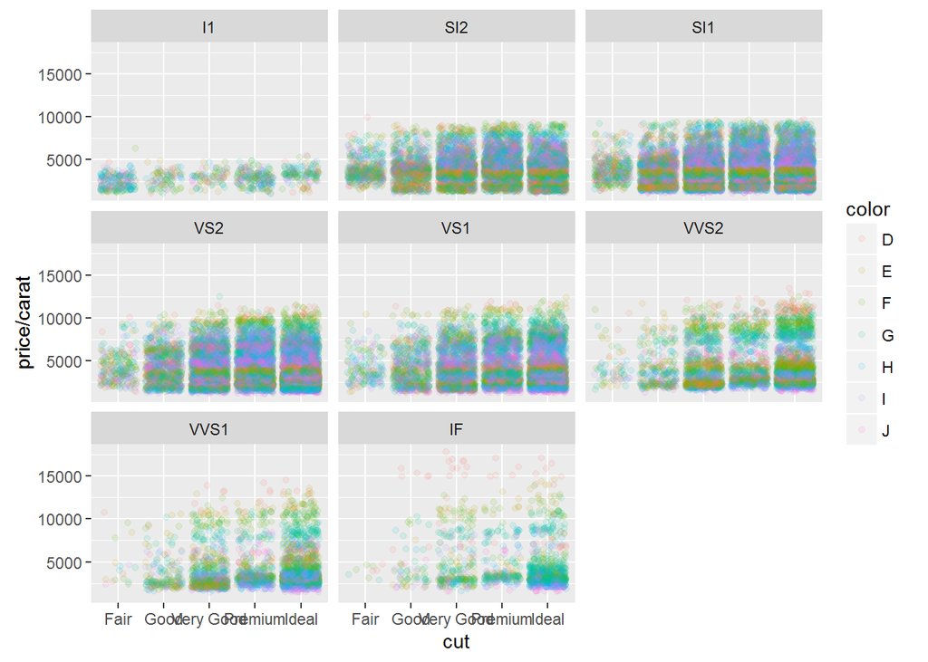

```r
ggplot(aes(y = price/carat, x = cut), data = diamonds) +
  geom_point(aes(color = color), alpha = 1/10, position = position_jitter(h = 5)) +
  facet_wrap(~ clarity)
```

## 11. Gapminder Multivariate Analysis

Create 2-5 plots that make use of the techniques from Lesson 5

Aid given per person for various countries between 1960 and 2007 (constant 2007 US$)

1. load csv, rename 1st column to something more managable, set NA’s to zero, examine results

```r
app <- read.csv("app.csv")
colnames(app)[1] <- "country"
app[is.na(app)] <- 0
app[1:5, 1:5]
```

```
##     country       X1960     X1961     X1962     X1963
## 1 Australia  51.6556420 60.145576 61.219626 75.614115
## 2   Austria   0.1914894  5.244006  3.967742  6.951253
## 3   Belgium 111.0918033 99.916122 74.030369 81.589882
## 4    Canada  24.6161164 23.418860 16.451023 24.773904
## 5   Denmark  16.2554585 23.707158 20.391398 22.179104
```

2. reshape data into long form. and examine results

```r
app.long <- gather(app, "year", "amount_per_person", X1960:X2007)
app.long$year <- as.numeric(substring(app.long$year, 2))
head(app.long)
```

```
##     country year amount_per_person
## 1 Australia 1960        51.6556420
## 2   Austria 1960         0.1914894
## 3   Belgium 1960       111.0918033
## 4    Canada 1960        24.6161164
## 5   Denmark 1960        16.2554585
## 6   Finland 1960         0.0000000
```

3. plot the amount per person by year for each country

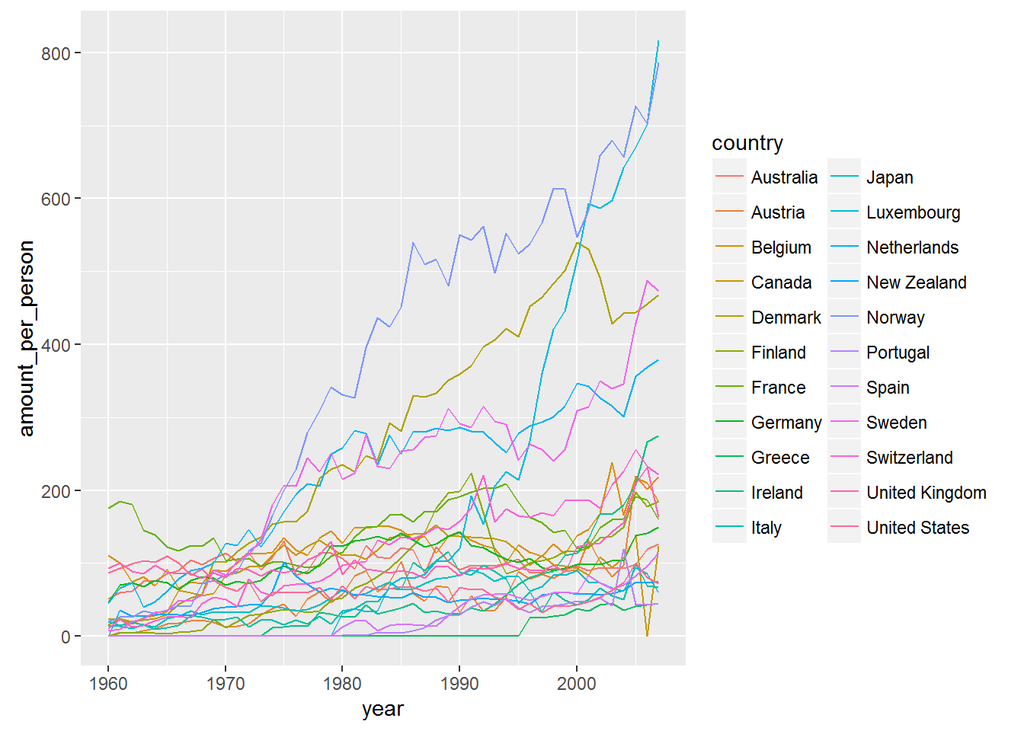

```r
ggplot(aes(x = year, y = amount_per_person), data = app.long)  +
  geom_line(aes(colour = country))
```

4. plot the average amount per person by year for all countries

```r
app.long.mean_year <- app.long %>%
  group_by(year) %>%
  summarise(mean_amount_per_person = mean(amount_per_person))
head(app.long.mean_year)
```

```
## Source: local data frame [6 x 2]
##
##    year mean_amount_per_person
##   (dbl)                  (dbl)
## 1  1960               32.94548
## 2  1961               38.77312
## 3  1962               36.85952
## 4  1963               35.93844
## 5  1964               36.86772
## 6  1965               39.80235
```

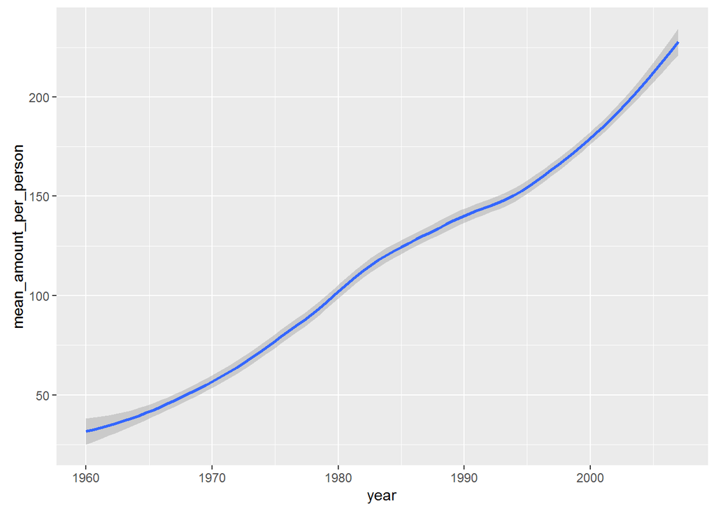

```r
ggplot(aes(x = year, y = mean_amount_per_person), data = app.long.mean_year)  +
  geom_smooth()
```

5. plot the amount per person by year by buckets of countries based on their mean amount per person

create mean amount per person for each country

```r
app.long.mean_country <- app.long %>%
  group_by(country) %>%
  summarise(mean_country = mean(amount_per_person))
head(app.long.mean_country)
```

```
## Source: local data frame [6 x 2]
##
##     country mean_country
##      (fctr)        (dbl)
## 1 Australia     98.17273
## 2   Austria     61.46056
## 3   Belgium    126.49121
## 4    Canada     97.81771
## 5   Denmark    268.54123
## 6   Finland     83.72672
```

create buckets of countries based on mean amount per person

```r
app.long.mean_country$country_bucket <- cut(app.long.mean_country$mean_country, breaks = 5)
```

combine new data set with long data set and examine the buckets

```r
app.long <- full_join(app.long, app.long.mean_country, by = "country")
summary(app.long$country_bucket)
```

```
## (8.62,80.8]  (80.8,153]   (153,224]   (224,296]   (296,368]
##         432         384         144          48          48
```

plot the graph, including a mean line

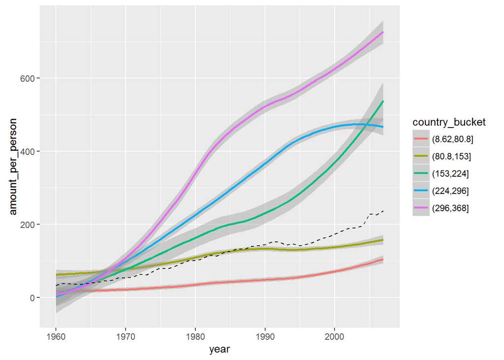

```r
ggplot(aes(x = year, y = amount_per_person), data = app.long)  +
  geom_smooth(aes(colour = country_bucket)) +
  geom_line(stat = "summary", fun.y = mean, linetype = 2)
```